# **The Simulation Analysis of the Solow Growth Model**

Mehmet Agah Caylan

13/01/2022

## **The Solow Growth Model**

The Solow Growth Model is a macroeconomic growth projection method with three main variables:  
*K* indicates the *capital stock*. *L* is the total *labor*. In this research the starting populations of all countries were presumed equal as one million.

For example, the sewing machine in a textile factory is a part of the capital stock and the person operating the machine is a unit of labor. In this research, we will include the total factor productivity which is shown by “A”.

Contemporary research always includes Human Capital as a variable. The idea of increasing human productiveness and its macroeconomic effects were put forth by Gary Becker. This research will not include the human capital. Nonetheless, the human capital is regarded as the most important variable in calculating the growth of developed countries, this research must be read taking this into consideration.

### **Parameters of the Solow Model**

Q Output  
A Productivity Parameter  
K Capital Stock  
L Labor / million  
I Investment  
S Savings

### **Simulations**

Previous year’s savings create the following year’s investment, so in the graphs, investment and savings overlap.

##### **Simulation Function One - Extremely Poor Country, 50000000 (50 million) dollars of initial GDP**

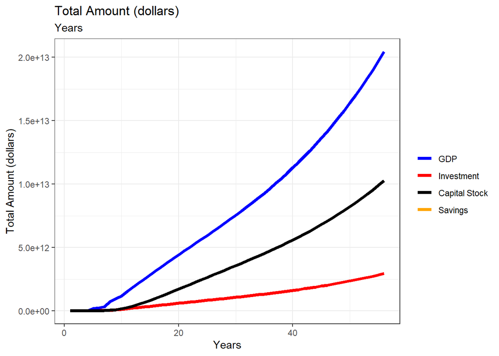

```r
sim_results1 <- simulation(50000000,1000000,1000000,10000,0,1)
simulation_function(sim_results1, "Total Amount (dollars)", "Years")
```

##### **Simulation Function Two - Relatively Poor Country, 100000000 (100 million) dollars of initial GDP**

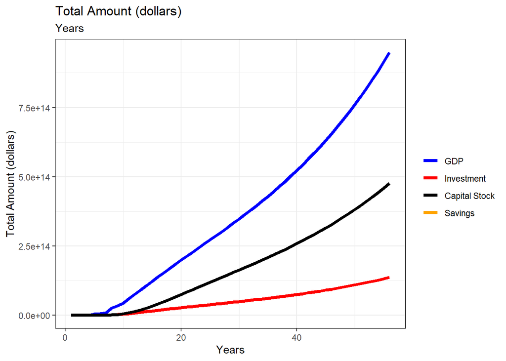

```r
sim_results2 <- simulation(100000000,1000000,1000000,100000,0,1)
simulation_function(sim_results2, "Total Amount (dollars)", "Years")
```

##### **Simulation Function Three - Average Income Country, 1000000000 (one billion) dollars of initial GDP**

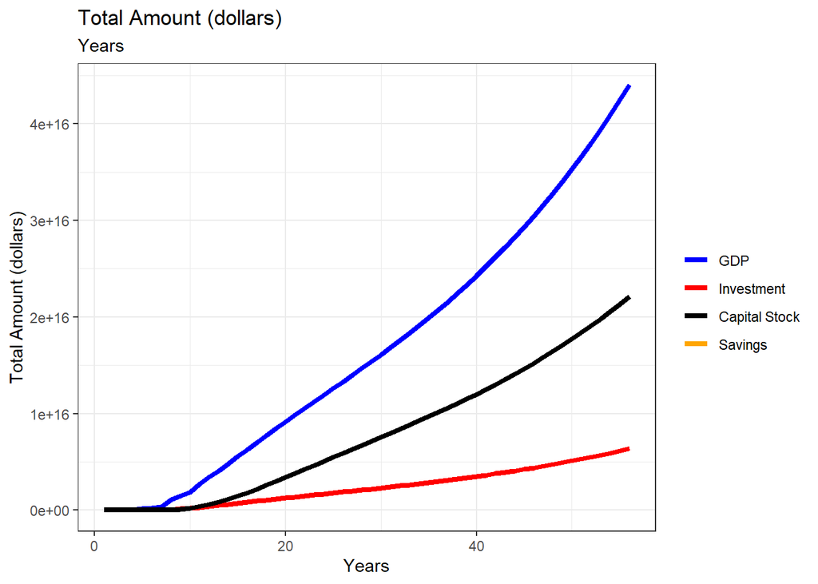

```r
sim_results3 <- simulation(1000000000,10000000,1000000,1000000,0,1)
simulation_function(sim_results3, "Total Amount (dollars)", "Years")
```

##### **Simulation Function Four - Relatively Rich Country, 12000000000 (twelve billion) dollars of initial GDP**

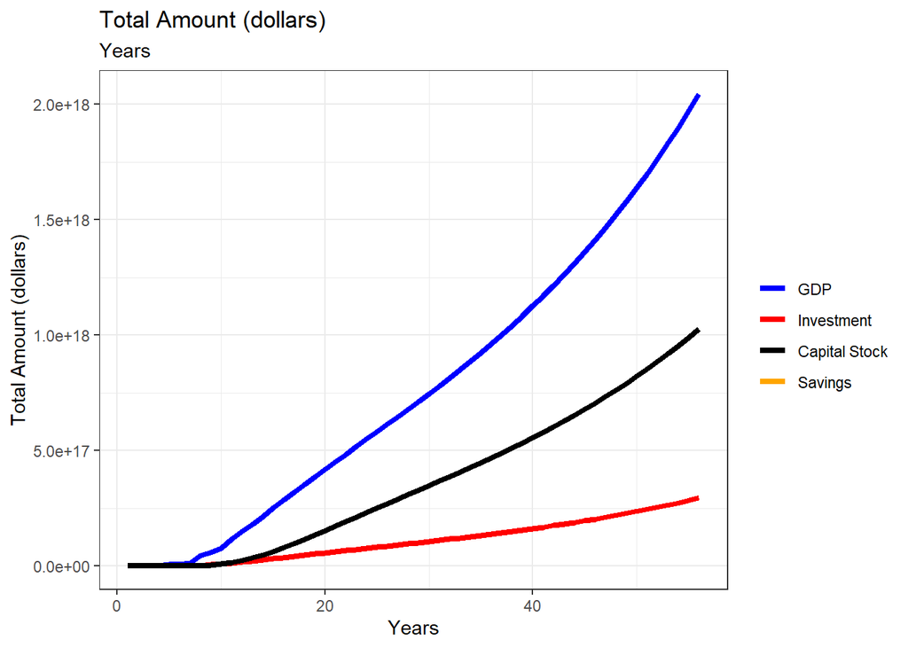

```r
sim_results4 <- simulation(12000000000,100000000,1000000,10000000,0,1)
simulation_function(sim_results4, "Total Amount (dollars)", "Years")
```